# Regression_Diagnostics_Exercise

Yuling Hsu

2023-02-13

Data: Effect of a raise in minimum wages on employment.

Conventional economic theory suggests that in a labour market with perfect competition an increase in the minimum wage leads to an increase in unemployment. In April 1992, the U.S. state of New Jersey (NJ) raised the minimum wage from $4.25 to $5.05. Card and Krueger (1994) use a DiD approach and show that this *increase in minimum wages* led to an *increase in employment* in the sector of fast food restaurants. The control group in their setting is the neighbouring U.S. state of Pennsylvania (PA), which was not subject to this policy change The authors conducted a survey before and after the raise of the minimum wage with a representative sample of fast food restaurants in NJ and PA. This setting can be regarded as quasi experimental, as both states are not identical in many aspects and the legislative procedure, in order the raise the minimum wage, was not initiated at random.

Ref: Card, David, and Alan B. Krueger. 1994. “Minimum Wages and Employment: A Case Study of the Fast-Food Industry in New Jersey and Pennsylvania.” The American Economic Review 84 (4): 772–93.

Load Data set

```r
card_krueger_1994_mod_data <- read.csv("card_krueger_1994.csv")
```

Q.1. Remove missing values from variables “empft”, “emppt”, “hrsopen”. Hint: Use filter() function (Refer to “Data Slicing and Dicing.RMD” lecture code.)

```r
library(dplyr)
df_filtered <- card_krueger_1994_mod_data %>%
  filter(!is.na(empft), !is.na(emppt), !is.na(hrsopen))
```

Q.2 Run the following linear regression model: “inctime = empft + emppt + hrsopen” using the above data.

```r
fit <- lm(inctime ~ empft + emppt + hrsopen, data = df_filtered)
summary(fit)
```

```
##
## Call:
## lm(formula = inctime ~ empft + emppt + hrsopen, data = df_filtered)
##
## Residuals:
##     Min      1Q  Median      3Q     Max
## -21.029  -7.941  -1.740   6.039  35.618
##
## Coefficients:
##             Estimate Std. Error t value Pr(>|t|)
## (Intercept) 11.31691    2.42782   4.661 3.76e-06 ***
## empft       -0.07758    0.06131  -1.265  0.20622
## emppt        0.07501    0.05057   1.483  0.13844
## hrsopen      0.54880    0.19403   2.828  0.00481 **
## ---
## Signif. codes:  0 '***' 0.001 '**' 0.01 '*' 0.05 '.' 0.1 ' ' 1
##
## Residual standard error: 12 on 707 degrees of freedom
##   (83 observations deleted due to missingness)
## Multiple R-squared:  0.02528,    Adjusted R-squared:  0.02114
## F-statistic: 6.112 on 3 and 707 DF,  p-value: 0.0004167
```

Q.3. Run regression diagnostic to ensure that regression is satisfying all the assumptions of OLS.

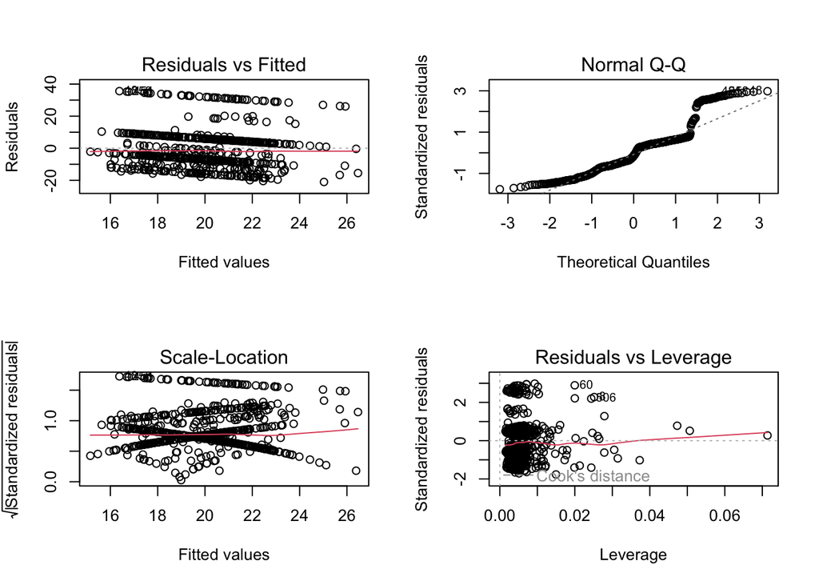

```r
#checking diagnostic plots
par(mfrow=c(2,2)) # Show plots in 2x2 grid.
plot(fit)
```

Q.4. Which assumption of OLS seems to be violated according to the plots of regression diagnostics (answer in plain english, no code). Answer:

Normal Q-Q plot: This plot compares the distribution of residuals to a normal distribution. If the plot shows a deviation from a straight line, it suggests that the normality assumption is violated.

Scale-Location plot: This plot shows the relationship between the square root of the standardized residuals and the fitted values. If the plot shows a pattern, it suggests that the homoscedasticity assumption is violated.

Q.5 Run a difference-in-difference model using “emptot” as y variable and “treated” as the treatment variable and “time” as the time variable.

```r
fit_dd = lm(emptot ~ time + treated + treated * time, data = df_filtered)
summary(fit_dd)
```

```
##
## Call:
## lm(formula = emptot ~ time + treated + treated * time, data = df_filtered)
##
## Residuals:
##     Min      1Q  Median      3Q     Max
## -15.831  -6.439  -0.944   4.236  64.561
##
## Coefficients:
##              Estimate Std. Error t value Pr(>|t|)
## (Intercept)    23.331      1.055  22.111   <2e-16 ***
## time           -1.887      1.497  -1.260   0.2079
## treated        -2.892      1.175  -2.461   0.0141 *
## time:treated    2.786      1.668   1.670   0.0953 .
## ---
## Signif. codes:  0 '***' 0.001 '**' 0.01 '*' 0.05 '.' 0.1 ' ' 1
##
## Residual standard error: 9.259 on 783 degrees of freedom
##   (7 observations deleted due to missingness)
## Multiple R-squared:  0.00806,    Adjusted R-squared:  0.00426
## F-statistic: 2.121 on 3 and 783 DF,  p-value: 0.09616
```

```r
fit_dd
```

```
##
## Call:
## lm(formula = emptot ~ time + treated + treated * time, data = df_filtered)
##
## Coefficients:
##  (Intercept)          time       treated  time:treated
##       23.331        -1.887        -2.892         2.786
```

Q.6 Generate a matched data using Propensity Score Matching (by macthing the propensity to be treated). Use the following variables for matching: empft, emppt, hrsopen, inctime

```r
library(MatchIt)
library(lmtest)
library(sandwich)

df_filtered <- df_filtered %>%
  filter(!is.na(inctime), !is.na(emppt))

sum(is.na(df_filtered$empft))
```

```
## [1] 0
```

```r
match_obj <- matchit(treated ~ empft + emppt + hrsopen + inctime,
  data = df_filtered,
  method = "nearest", # "nearest" for nearest neighbor matching
  distance ="glm", # name of a method of estimating propensity scores (e.g., "glm")
  ratio = 1, # ratio: how many control units should be matched to each treated unit
  replace = TRUE) # replace: whether matching should be done with replacement (TRUE)
?matchit
summary(match_obj)
```

```
##
## Call:
## matchit(formula = treated ~ empft + emppt + hrsopen + inctime,
##     data = df_filtered, method = "nearest", distance = "glm",
##     replace = TRUE, ratio = 1)
##
## Summary of Balance for All Data:
##          Means Treated Means Control Std. Mean Diff. Var. Ratio eCDF Mean
## distance        0.8041        0.7991          0.1846     0.7033    0.0393
## empft           8.2872        9.1464         -0.1094     0.6262    0.0342
## emppt          18.5657       19.5321         -0.0926     1.2487    0.0385
## hrsopen        14.4737       14.5214         -0.0176     0.8312    0.0323
## inctime        20.0333       19.9464          0.0072     0.9219    0.0186
##          eCDF Max
## distance   0.0710
## empft      0.0746
## emppt      0.1135
## hrsopen    0.1157
## inctime    0.0584
##
## Summary of Balance for Matched Data:
##          Means Treated Means Control Std. Mean Diff. Var. Ratio eCDF Mean
## distance        0.8041        0.8041         -0.0009     1.0193    0.0043
## empft           8.2872        8.2653          0.0028     0.7914    0.0332
## emppt          18.5657       19.5140         -0.0908     1.3092    0.0395
## hrsopen        14.4737       14.8888         -0.1529     0.8564    0.0363
## inctime        20.0333       20.3424         -0.0257     0.8959    0.0188
##          eCDF Max Std. Pair Dist.
## distance   0.0315          0.0218
## empft      0.1103          0.8892
## emppt      0.0998          0.8918
## hrsopen    0.1419          1.1638
## inctime    0.0403          1.0270
##
## Sample Sizes:
##               Control Treated
## All            140.       571
## Matched (ESS)   81.61     571
## Matched        124.       571
## Unmatched       16.         0
## Discarded        0.         0
```

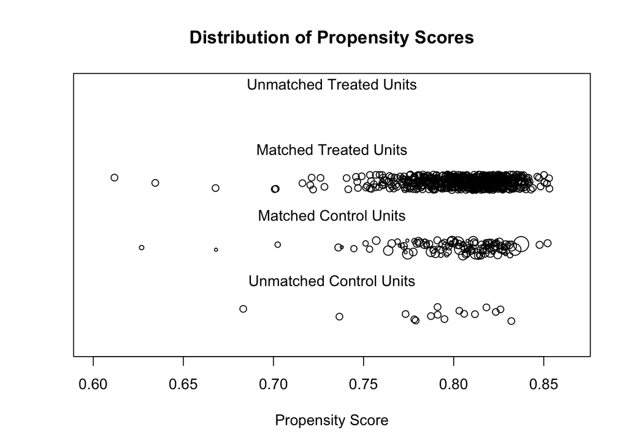

```r
plot(match_obj, type = "jitter", interactive = FALSE)
```

```r
#Extract the matched data and save the data into the variable matched_data
matched_data <- match.data(match_obj)
```

Q.7. Run the difference-in-difference model on the matched data.

```r
didreg1 = lm(emptot ~ time + treated + treated * time, data = matched_data)
summary(didreg1)
```

```
##
## Call:
## lm(formula = emptot ~ time + treated + treated * time, data = matched_data)
##
## Residuals:
##     Min      1Q  Median      3Q     Max
## -15.848  -6.150  -1.150   4.137  64.350
##
## Coefficients:
##              Estimate Std. Error t value Pr(>|t|)
## (Intercept)    23.348      1.124  20.773   <2e-16 ***
## time           -1.914      1.651  -1.159   0.2467
## treated        -2.698      1.243  -2.172   0.0302 *
## time:treated    2.711      1.822   1.488   0.1371
## ---
## Signif. codes:  0 '***' 0.001 '**' 0.01 '*' 0.05 '.' 0.1 ' ' 1
##
## Residual standard error: 9.131 on 684 degrees of freedom
##   (7 observations deleted due to missingness)
## Multiple R-squared:  0.007122,   Adjusted R-squared:  0.002767
## F-statistic: 1.635 on 3 and 684 DF,  p-value: 0.1799
```